# Confidence in Banks by Class

Christian Tamayo

April 20, 2015

### Introduction:

Turn on any news outlet today, and chances are high that you will hear about the “shrinking middle class” or about income inequality. In 2008, the economy took a nose dive due to realization that the housing sector wasn’t quite worth what people had been led to believe. People of all classes were affected by this crisis.

In this midst of all these issues are our banking/financial institutions. They are involved wherever our money is, from holding, investing, lending, and so forth. Upper class individuals likely explore their services more so than lower class customers do. They are often at the forefront of any crisis. Is there a relationship between a person’s perceived class and their confidence in the banking/financial institutions? With the majority of people perceiving themselves to be below upper class and our economy dependent on those banking choices, it is important to see how they view this important sector.

### Data:

The data for this project comes from the General Social Survey (GSS), which is a large scale survey taken nearly every year from 1972-1994, and every two years since. Interviewees are English/Spanish speaking individuals over 18 and from metropolitan and rural areas of the United States. Interviews were conducted face-to-face, by telephone, and using computers since 2002. The target sample size has been 1500 each round.

This project will focus on years 2002-2012.

Each is a person surveyed. They will indicate what class they perceive themselves to be (Lower Class, Working Class, Middle Class, and Upper Class) as well as their confidence in the banking/financial institutions (A Great Deal, Only Some, Hardly Any). The variables “class” and “confidence in financial institutions” are both categorical and ordinal.

The study was a survey, so it is observational. While it can find a correlation between variables, it cannot establish causality.

The survey used random samples, however, so its findings can be generalized to the entire US population.

### Exploratory data analysis:

Looking at the variable of class (since 2002), the majority of respondents view themselves as “working” or “middle” class, with the numbers of “Lower” and “Upper” being considerably smaller.

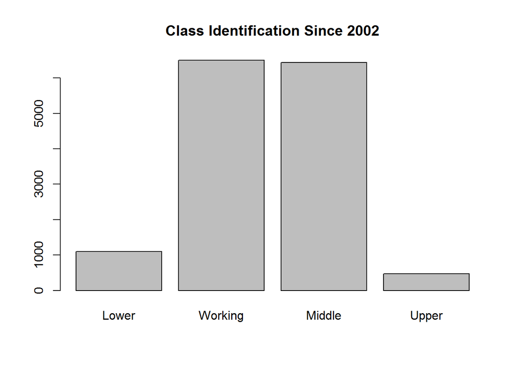

```r
barplot(table(noclasssince), main = 'Class Identification Since 2002')
```

Similar to the class variable, people’s overall confidence in the banking/financial institutions (since 2002) falls near the middle to “Only Some”, where the numbers for “Hardly Any” and “A Great Deal” much fewer.

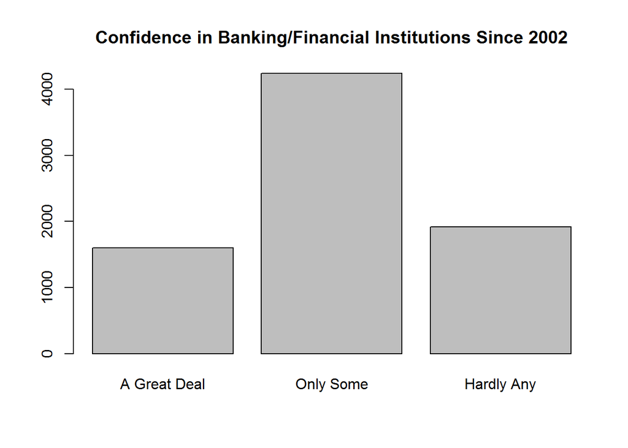

```r
barplot(table(gss$confinan[gss$year > 2001]), main = 'Confidence in Banking/Financial Institutions Since 2002')
```

Below is a frequency table and a mosaic plot of the two variables.

```r
addmargins(table(gss$confinan[gss$year > 2001],noclasssince, deparse.level = 0))
```

```
##
##                Lower Working Middle Upper  Sum
##   A Great Deal    98     669    742    81 1590
##   Only Some      323    1919   1846   135 4223
##   Hardly Any     221     923    720    39 1903
##   Sum            642    3511   3308   255 7716
```

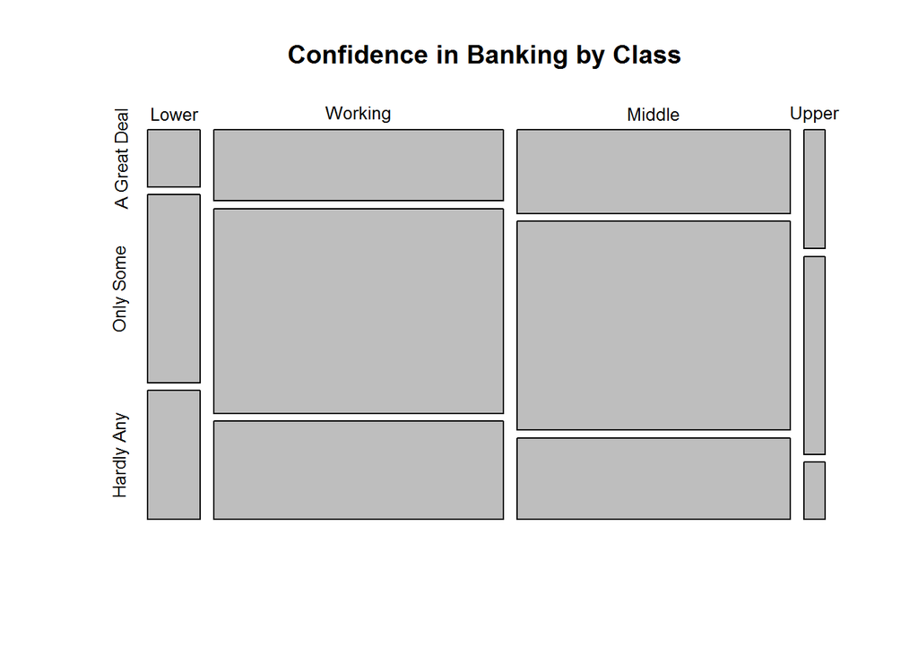

```r
mosaicplot(table( noclasssince, gss$confinan[gss$year > 2001], deparse.level = 0),  cex.axis = .8, main = 'Confidence in Banking by Class')
```

While it seems the default, in general, is to be somewhere in the middle in both confidence and class, do they correlate? Are the few people with no confidence in the banking institutions also the few people who consider themselves “Lower Class”?